# FM-index-prj

This is a script that do the FM index referring to a file FASTA (DNA or RNA).

Below there are a short descriptions of all the function created.

This is the class that contain all the functions

```python
class FM_index():
  ...
```

The function

```python
def rules():
  ...
```

it provides to print on terminal the main rules for correctly use the script.

The function

```python
def dir_creation():
  ...
```

it provides to create the source directory where inside it are saved all the sequence file obtained as output by all the other function

The function

```python
def readFile():
  ...
```

it provides to the reading part of the input file. The function splitted in two part: the first one corresponds to the fact that the executor has the FASTA file on his computer; the second one corresponds to the fact that the executor doesn’t have the FASTA file, but he has the NCBI code of the sequence (so he thanks to the API he can use the code to take the FASTA file)

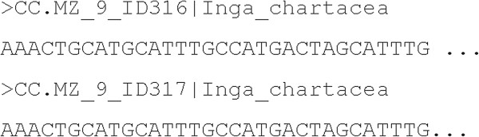

The function

```python
def single_file_directory().
  ...
```

it provides to create a directory named with the header of the FASTA file and save it inside the the source directory previously created.

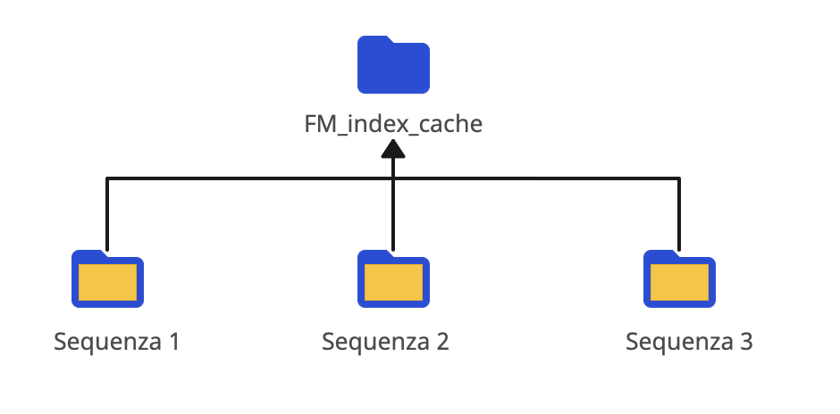

The function provides to obtain the data for create a dataframe.

```python
def suffix_array():
  ...
```

The suffix is a sorted array (SA) of all suffixes of a string. It is a simple space efficient alternative to suffix trees.

The function

```python
def LCPArray():
  ...
```

it provides to create the longest common prefixes array (LCPA). It is an auxiliary data structure to the suffix array. It stores the lengths of the longest common prefixes (LCPs) between all pairs of consecutive suffixes in a sorted suffix array.

The function

```python
def BWTransform():
  ...
```

it provides to do the borrows wheeler transform of the FASTA file. Rearranges a character string into runs of similar characters. This is useful for compression! More importantly, the transformation is reversible, without needing to store any additional data except the position of the first original character. The BWT is thus a “free” method of improving the efficiency of text compression algorithms, costing only some extra computation. The transform is done by sorting all the circular shifts of a text in lexicographic order and by extracting the last column and the index of the original string in the set of sorted permutations of the start text.

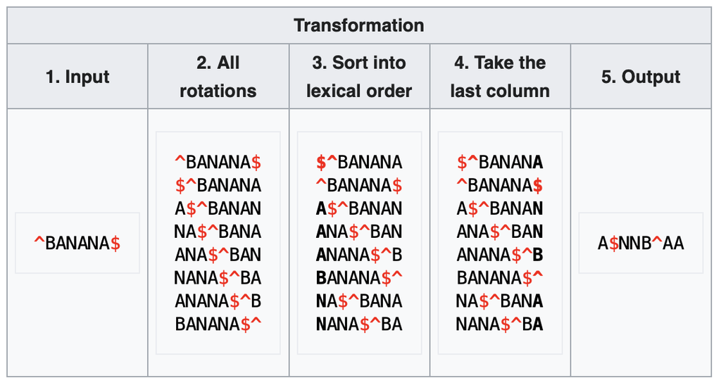

The function

```python
def C_c():
  ...
```

it provides to create a dataframe, is a table that, for each character c in the alphabet, contains the number of occurrences of lexically smaller characters in the text.

The function [Occ(c, k)]

```python
def Occ_matrix():
  ...
```

it is the number of occurrences of character c in the prefix L[1..k]. Ferragina and Manzini (the creator of this method) showed that it is possible to compute Occ(c, k) in constant time.

The function

```python
def pattern_input():
  ...
```

it provides to take as input a list of pattern that the executor wants search inside the FASTA sequence.

The function

```python
def binary_search_for_pattern():
  ...
```

is a normal binary search method which allows to find the first index (position) of the pattern inside the sequence and also can allows to find all the indexes (positions) of the pattern.

The function

```python
def backward_search_for_pattern():
  ...
```

using the structure previously created it provides to calculate the number of occurrences of the pattern inside the sequence.

The function

```python
def final_results():
  ...
```

it provides to take the output of the functions binary search and backward search and stores them in a dataframe.

The function

```python
def DNA_plot():
  ...
```

provides for tracing the patterns found along the entire length of the sequence.

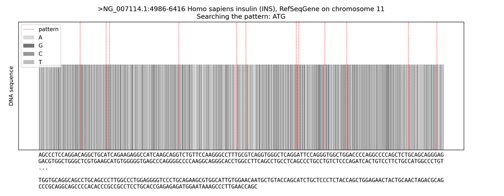

The function

```python
def save():
  ...
```

it provide to save all the results in the correct folder.